# EDA PART-1

<h1 id="Importing-required-libraries">Importing required libraries</h1>

```python
import pandas as pd
import numpy as np
```

<h1 id="Loading-the-dataset">Loading the dataset</h1>

```python
df = pd.read_csv("data.csv",encoding = 'ISO-8859-1')
```

```python
df
```

<style scoped> .dataframe tbody tr th:only-of-type { vertical-align: middle; } .dataframe tbody tr th { vertical-align: top; } .dataframe thead th { text-align: right; } </style> <thead> <th></th> <th>InvoiceNo</th> <th>StockCode</th> <th>Description</th> <th>Quantity</th> <th>InvoiceDate</th> <th>UnitPrice</th> <th>CustomerID</th> <th>Country</th> </thead> <tbody> <th>0</th> <th>1</th> <th>2</th> <th>3</th> <th>4</th> <th>...</th> <th>541904</th> <th>541905</th> <th>541906</th> <th>541907</th> <th>541908</th> </tbody>

| 536365 | 85123A | WHITE HANGING HEART T-LIGHT HOLDER | 6 | 12/1/2010 8:26 | 2.55 | 17850.0 | United Kingdom |
| --- | --- | --- | --- | --- | --- | --- | --- |
| 536365 | 71053 | WHITE METAL LANTERN | 6 | 12/1/2010 8:26 | 3.39 | 17850.0 | United Kingdom |
| 536365 | 84406B | CREAM CUPID HEARTS COAT HANGER | 8 | 12/1/2010 8:26 | 2.75 | 17850.0 | United Kingdom |
| 536365 | 84029G | KNITTED UNION FLAG HOT WATER BOTTLE | 6 | 12/1/2010 8:26 | 3.39 | 17850.0 | United Kingdom |
| 536365 | 84029E | RED WOOLLY HOTTIE WHITE HEART. | 6 | 12/1/2010 8:26 | 3.39 | 17850.0 | United Kingdom |
| ... | ... | ... | ... | ... | ... | ... | ... |
| 581587 | 22613 | PACK OF 20 SPACEBOY NAPKINS | 12 | 12/9/2011 12:50 | 0.85 | 12680.0 | France |
| 581587 | 22899 | CHILDREN'S APRON DOLLY GIRL | 6 | 12/9/2011 12:50 | 2.10 | 12680.0 | France |
| 581587 | 23254 | CHILDRENS CUTLERY DOLLY GIRL | 4 | 12/9/2011 12:50 | 4.15 | 12680.0 | France |
| 581587 | 23255 | CHILDRENS CUTLERY CIRCUS PARADE | 4 | 12/9/2011 12:50 | 4.15 | 12680.0 | France |
| 581587 | 22138 | BAKING SET 9 PIECE RETROSPOT | 3 | 12/9/2011 12:50 | 4.95 | 12680.0 | France |

<p>541909 rows × 8 columns</p>

```python
df.shape
```

```
(541909, 8)
```

<h1 id="Access-first-5-rows">Access first 5 rows</h1>

```python
df.head()
```

<style scoped> .dataframe tbody tr th:only-of-type { vertical-align: middle; } .dataframe tbody tr th { vertical-align: top; } .dataframe thead th { text-align: right; } </style> <thead> <th></th> <th>InvoiceNo</th> <th>StockCode</th> <th>Description</th> <th>Quantity</th> <th>InvoiceDate</th> <th>UnitPrice</th> <th>CustomerID</th> <th>Country</th> </thead> <tbody> <th>0</th> <th>1</th> <th>2</th> <th>3</th> <th>4</th> </tbody>

| 536365 | 85123A | WHITE HANGING HEART T-LIGHT HOLDER | 6 | 12/1/2010 8:26 | 2.55 | 17850.0 | United Kingdom |
| --- | --- | --- | --- | --- | --- | --- | --- |
| 536365 | 71053 | WHITE METAL LANTERN | 6 | 12/1/2010 8:26 | 3.39 | 17850.0 | United Kingdom |
| 536365 | 84406B | CREAM CUPID HEARTS COAT HANGER | 8 | 12/1/2010 8:26 | 2.75 | 17850.0 | United Kingdom |
| 536365 | 84029G | KNITTED UNION FLAG HOT WATER BOTTLE | 6 | 12/1/2010 8:26 | 3.39 | 17850.0 | United Kingdom |
| 536365 | 84029E | RED WOOLLY HOTTIE WHITE HEART. | 6 | 12/1/2010 8:26 | 3.39 | 17850.0 | United Kingdom |

<h1 id="Access-last-5-rows">Access last 5 rows</h1>

```python
df.tail()
```

<style scoped> .dataframe tbody tr th:only-of-type { vertical-align: middle; } .dataframe tbody tr th { vertical-align: top; } .dataframe thead th { text-align: right; } </style> <thead> <th></th> <th>InvoiceNo</th> <th>StockCode</th> <th>Description</th> <th>Quantity</th> <th>InvoiceDate</th> <th>UnitPrice</th> <th>CustomerID</th> <th>Country</th> </thead> <tbody> <th>541904</th> <th>541905</th> <th>541906</th> <th>541907</th> <th>541908</th> </tbody>

| 581587 | 22613 | PACK OF 20 SPACEBOY NAPKINS | 12 | 12/9/2011 12:50 | 0.85 | 12680.0 | France |
| --- | --- | --- | --- | --- | --- | --- | --- |
| 581587 | 22899 | CHILDREN'S APRON DOLLY GIRL | 6 | 12/9/2011 12:50 | 2.10 | 12680.0 | France |
| 581587 | 23254 | CHILDRENS CUTLERY DOLLY GIRL | 4 | 12/9/2011 12:50 | 4.15 | 12680.0 | France |
| 581587 | 23255 | CHILDRENS CUTLERY CIRCUS PARADE | 4 | 12/9/2011 12:50 | 4.15 | 12680.0 | France |
| 581587 | 22138 | BAKING SET 9 PIECE RETROSPOT | 3 | 12/9/2011 12:50 | 4.95 | 12680.0 | France |

<h1 id="list-of-all-columns">list of all columns</h1>

```python
df.columns
```

```
Index(['InvoiceNo', 'StockCode', 'Description', 'Quantity', 'InvoiceDate',
       'UnitPrice', 'CustomerID', 'Country'],
      dtype='str')
```

```python
d={
    'InvoiceNo': 'invoice_num',
    'StockCode': 'stock_code',
    'Description': 'description',
    'Quantity': 'quantity',
    'InvoiceDate': 'invoice_date',
    'UnitPrice':'unit_price',
    'CustomerID': 'cust_id',
    'Country': 'country'
}
```

```python
d
```

```
{'InvoiceNo': 'invoice_num',
 'StockCode': 'stock_code',
 'Description': 'description',
 'Quantity': 'quantity',
 'InvoiceDate': 'invoice_date',
 'UnitPrice': 'unit_price',
 'CustomerID': 'cust_id',
 'Country': 'country'}
```

```python
df.rename(columns=d,inplace=True)
```

<h1 id="After-renaming-columns-printing-DataFrame">After renaming columns printing DataFrame</h1>

```python
df
```

<style scoped> .dataframe tbody tr th:only-of-type { vertical-align: middle; } .dataframe tbody tr th { vertical-align: top; } .dataframe thead th { text-align: right; } </style> <thead> <th></th> <th>invoice_num</th> <th>stock_code</th> <th>description</th> <th>quantity</th> <th>invoice_date</th> <th>unit_price</th> <th>cust_id</th> <th>country</th> </thead> <tbody> <th>0</th> <th>1</th> <th>2</th> <th>3</th> <th>4</th> <th>...</th> <th>541904</th> <th>541905</th> <th>541906</th> <th>541907</th> <th>541908</th> </tbody>

| 536365 | 85123A | WHITE HANGING HEART T-LIGHT HOLDER | 6 | 12/1/2010 8:26 | 2.55 | 17850.0 | United Kingdom |
| --- | --- | --- | --- | --- | --- | --- | --- |
| 536365 | 71053 | WHITE METAL LANTERN | 6 | 12/1/2010 8:26 | 3.39 | 17850.0 | United Kingdom |
| 536365 | 84406B | CREAM CUPID HEARTS COAT HANGER | 8 | 12/1/2010 8:26 | 2.75 | 17850.0 | United Kingdom |
| 536365 | 84029G | KNITTED UNION FLAG HOT WATER BOTTLE | 6 | 12/1/2010 8:26 | 3.39 | 17850.0 | United Kingdom |
| 536365 | 84029E | RED WOOLLY HOTTIE WHITE HEART. | 6 | 12/1/2010 8:26 | 3.39 | 17850.0 | United Kingdom |
| ... | ... | ... | ... | ... | ... | ... | ... |
| 581587 | 22613 | PACK OF 20 SPACEBOY NAPKINS | 12 | 12/9/2011 12:50 | 0.85 | 12680.0 | France |
| 581587 | 22899 | CHILDREN'S APRON DOLLY GIRL | 6 | 12/9/2011 12:50 | 2.10 | 12680.0 | France |
| 581587 | 23254 | CHILDRENS CUTLERY DOLLY GIRL | 4 | 12/9/2011 12:50 | 4.15 | 12680.0 | France |
| 581587 | 23255 | CHILDRENS CUTLERY CIRCUS PARADE | 4 | 12/9/2011 12:50 | 4.15 | 12680.0 | France |
| 581587 | 22138 | BAKING SET 9 PIECE RETROSPOT | 3 | 12/9/2011 12:50 | 4.95 | 12680.0 | France |

<p>541909 rows × 8 columns</p>

<h1 id="Lets-check-initial-data-or-checking-top-5-rows-in-DataFrame">Lets check initial data or checking top 5 rows in DataFrame</h1>

```python
df.head()
```

<style scoped> .dataframe tbody tr th:only-of-type { vertical-align: middle; } .dataframe tbody tr th { vertical-align: top; } .dataframe thead th { text-align: right; } </style> <thead> <th></th> <th>invoice_num</th> <th>stock_code</th> <th>description</th> <th>quantity</th> <th>invoice_date</th> <th>unit_price</th> <th>cust_id</th> <th>country</th> </thead> <tbody> <th>0</th> <th>1</th> <th>2</th> <th>3</th> <th>4</th> </tbody>

| 536365 | 85123A | WHITE HANGING HEART T-LIGHT HOLDER | 6 | 12/1/2010 8:26 | 2.55 | 17850.0 | United Kingdom |
| --- | --- | --- | --- | --- | --- | --- | --- |
| 536365 | 71053 | WHITE METAL LANTERN | 6 | 12/1/2010 8:26 | 3.39 | 17850.0 | United Kingdom |
| 536365 | 84406B | CREAM CUPID HEARTS COAT HANGER | 8 | 12/1/2010 8:26 | 2.75 | 17850.0 | United Kingdom |
| 536365 | 84029G | KNITTED UNION FLAG HOT WATER BOTTLE | 6 | 12/1/2010 8:26 | 3.39 | 17850.0 | United Kingdom |
| 536365 | 84029E | RED WOOLLY HOTTIE WHITE HEART. | 6 | 12/1/2010 8:26 | 3.39 | 17850.0 | United Kingdom |

<h1 id="Data-Cleaning-operations">Data Cleaning operations</h1>

```python
df.dtypes
```

```
invoice_num         str
stock_code          str
description         str
quantity          int64
invoice_date        str
unit_price      float64
cust_id         float64
country             str
dtype: object
```

```python
"""
here what we can analyse from the dtypes is that:
    1.invoice data should be in datetime format
    2.generally cust_id should be integer
"""
```

```
'\nhere what we can analyse from the dtypes is that:\n    1.invoice data should be in datetime format\n    2.generally cust_id should be integer\n'
```

<h1 id="DataFrame-information">DataFrame information</h1>

```python
df.info()
```

```
<class 'pandas.DataFrame'>
RangeIndex: 541909 entries, 0 to 541908
Data columns (total 8 columns):
 #   Column        Non-Null Count   Dtype
---  ------        --------------   -----
 0   invoice_num   541909 non-null  str
 1   stock_code    541909 non-null  str
 2   description   540455 non-null  str
 3   quantity      541909 non-null  int64
 4   invoice_date  541909 non-null  str
 5   unit_price    541909 non-null  float64
 6   cust_id       406829 non-null  float64
 7   country       541909 non-null  str
dtypes: float64(2), int64(1), str(5)
memory usage: 33.1 MB
```

<h1 id="description,cust_ID-have-some-missing-values.Therefore-descripition-was-optional.But-cust_id-is-missing-which-is-a-serious-concern.-i.e-we-have-to-do-some-R&D-and-ask-to-the-data-provider(client).-why-customers-are-missing.Eg:-There-might-be-some-vip-ids-whose-data-is-hided%22%22%22">description,cust_ID have some missing values.Therefore descripition was optional.But cust_id is missing which is a serious concern. i.e we have to do some R&D and ask to the data provider(client). why customers are missing.Eg:-There might be some vip ids whose data is hided"""</h1>

```python
df.isna()
```

<style scoped> .dataframe tbody tr th:only-of-type { vertical-align: middle; } .dataframe tbody tr th { vertical-align: top; } .dataframe thead th { text-align: right; } </style> <thead> <th></th> <th>invoice_num</th> <th>stock_code</th> <th>description</th> <th>quantity</th> <th>invoice_date</th> <th>unit_price</th> <th>cust_id</th> <th>country</th> </thead> <tbody> <th>0</th> <th>1</th> <th>2</th> <th>3</th> <th>4</th> <th>...</th> <th>541904</th> <th>541905</th> <th>541906</th> <th>541907</th> <th>541908</th> </tbody>

| False | False | False | False | False | False | False | False |
| --- | --- | --- | --- | --- | --- | --- | --- |
| False | False | False | False | False | False | False | False |
| False | False | False | False | False | False | False | False |
| False | False | False | False | False | False | False | False |
| False | False | False | False | False | False | False | False |
| ... | ... | ... | ... | ... | ... | ... | ... |
| False | False | False | False | False | False | False | False |
| False | False | False | False | False | False | False | False |
| False | False | False | False | False | False | False | False |
| False | False | False | False | False | False | False | False |
| False | False | False | False | False | False | False | False |

<p>541909 rows × 8 columns</p>

```python
df.isna().sum()
```

```
invoice_num          0
stock_code           0
description       1454
quantity             0
invoice_date         0
unit_price           0
cust_id         135080
country              0
dtype: int64
```

<h1 id="we-came-to-the-conclusion-of-no-of-missing-values">we came to the conclusion of no of missing values</h1>

```python
df.isna().sum().sort_values()
```

```
invoice_num          0
stock_code           0
quantity             0
invoice_date         0
country              0
unit_price           0
description       1454
cust_id         135080
dtype: int64
```

```python
df.isna().sum().sort_values(ascending=False)
```

```
cust_id         135080
description       1454
stock_code           0
invoice_num          0
quantity             0
invoice_date         0
unit_price           0
country              0
dtype: int64
```

```python
#this is how we have to reach out to client with data.by keeping most missed values at top
```

```python
df.dtypes
```

```
invoice_num         str
stock_code          str
description         str
quantity          int64
invoice_date        str
unit_price      float64
cust_id         float64
country             str
dtype: object
```

```python
df['invoice_date']=pd.to_datetime(df['invoice_date'],format='%m/%d/%Y %H:%M')
```

```python
df.dtypes
```

```
invoice_num                str
stock_code                 str
description                str
quantity                 int64
invoice_date    datetime64[us]
unit_price             float64
cust_id                float64
country                    str
dtype: object
```

```python
df.head(2)
```

<style scoped> .dataframe tbody tr th:only-of-type { vertical-align: middle; } .dataframe tbody tr th { vertical-align: top; } .dataframe thead th { text-align: right; } </style> <thead> <th></th> <th>invoice_num</th> <th>stock_code</th> <th>description</th> <th>quantity</th> <th>invoice_date</th> <th>unit_price</th> <th>cust_id</th> <th>country</th> </thead> <tbody> <th>0</th> <th>1</th> </tbody>

| 536365 | 85123A | WHITE HANGING HEART T-LIGHT HOLDER | 6 | 2010-12-01 08:26:00 | 2.55 | 17850.0 | United Kingdom |
| --- | --- | --- | --- | --- | --- | --- | --- |
| 536365 | 71053 | WHITE METAL LANTERN | 6 | 2010-12-01 08:26:00 | 3.39 | 17850.0 | United Kingdom |

<h1 id="we-have-sucesfully-converted-datetime-coulum">we have sucesfully converted datetime coulum</h1>

```python
df.description
```

```
0          WHITE HANGING HEART T-LIGHT HOLDER
1                         WHITE METAL LANTERN
2              CREAM CUPID HEARTS COAT HANGER
3         KNITTED UNION FLAG HOT WATER BOTTLE
4              RED WOOLLY HOTTIE WHITE HEART.
                         ...
541904            PACK OF 20 SPACEBOY NAPKINS
541905           CHILDREN'S APRON DOLLY GIRL
541906          CHILDRENS CUTLERY DOLLY GIRL
541907        CHILDRENS CUTLERY CIRCUS PARADE
541908          BAKING SET 9 PIECE RETROSPOT
Name: description, Length: 541909, dtype: str
```

```python
df.description.str.lower() #we need to convert description to lower case
```

```
0          white hanging heart t-light holder
1                         white metal lantern
2              cream cupid hearts coat hanger
3         knitted union flag hot water bottle
4              red woolly hottie white heart.
                         ...
541904            pack of 20 spaceboy napkins
541905           children's apron dolly girl
541906          childrens cutlery dolly girl
541907        childrens cutlery circus parade
541908          baking set 9 piece retrospot
Name: description, Length: 541909, dtype: str
```

```python
df.head()
```

<style scoped> .dataframe tbody tr th:only-of-type { vertical-align: middle; } .dataframe tbody tr th { vertical-align: top; } .dataframe thead th { text-align: right; } </style> <thead> <th></th> <th>invoice_num</th> <th>stock_code</th> <th>description</th> <th>quantity</th> <th>invoice_date</th> <th>unit_price</th> <th>cust_id</th> <th>country</th> </thead> <tbody> <th>0</th> <th>1</th> <th>2</th> <th>3</th> <th>4</th> </tbody>

| 536365 | 85123A | WHITE HANGING HEART T-LIGHT HOLDER | 6 | 2010-12-01 08:26:00 | 2.55 | 17850.0 | United Kingdom |
| --- | --- | --- | --- | --- | --- | --- | --- |
| 536365 | 71053 | WHITE METAL LANTERN | 6 | 2010-12-01 08:26:00 | 3.39 | 17850.0 | United Kingdom |
| 536365 | 84406B | CREAM CUPID HEARTS COAT HANGER | 8 | 2010-12-01 08:26:00 | 2.75 | 17850.0 | United Kingdom |
| 536365 | 84029G | KNITTED UNION FLAG HOT WATER BOTTLE | 6 | 2010-12-01 08:26:00 | 3.39 | 17850.0 | United Kingdom |
| 536365 | 84029E | RED WOOLLY HOTTIE WHITE HEART. | 6 | 2010-12-01 08:26:00 | 3.39 | 17850.0 | United Kingdom |

```python
df['description'] = df.description.str.lower()
```

```python
df.head()
```

<style scoped> .dataframe tbody tr th:only-of-type { vertical-align: middle; } .dataframe tbody tr th { vertical-align: top; } .dataframe thead th { text-align: right; } </style> <thead> <th></th> <th>invoice_num</th> <th>stock_code</th> <th>description</th> <th>quantity</th> <th>invoice_date</th> <th>unit_price</th> <th>cust_id</th> <th>country</th> </thead> <tbody> <th>0</th> <th>1</th> <th>2</th> <th>3</th> <th>4</th> </tbody>

| 536365 | 85123A | white hanging heart t-light holder | 6 | 2010-12-01 08:26:00 | 2.55 | 17850.0 | United Kingdom |
| --- | --- | --- | --- | --- | --- | --- | --- |
| 536365 | 71053 | white metal lantern | 6 | 2010-12-01 08:26:00 | 3.39 | 17850.0 | United Kingdom |
| 536365 | 84406B | cream cupid hearts coat hanger | 8 | 2010-12-01 08:26:00 | 2.75 | 17850.0 | United Kingdom |
| 536365 | 84029G | knitted union flag hot water bottle | 6 | 2010-12-01 08:26:00 | 3.39 | 17850.0 | United Kingdom |
| 536365 | 84029E | red woolly hottie white heart. | 6 | 2010-12-01 08:26:00 | 3.39 | 17850.0 | United Kingdom |

<h1 id="based-on-clint-discussion-team-meating-we-need-to-perform-action-for-missing-values">based on clint discussion team meating we need to perform action for missing values</h1>

```python
df_new = df.dropna()
```

```python
df_new.info()
```

```
<class 'pandas.DataFrame'>
Index: 406829 entries, 0 to 541908
Data columns (total 8 columns):
 #   Column        Non-Null Count   Dtype
---  ------        --------------   -----
 0   invoice_num   406829 non-null  str
 1   stock_code    406829 non-null  str
 2   description   406829 non-null  str
 3   quantity      406829 non-null  int64
 4   invoice_date  406829 non-null  datetime64[us]
 5   unit_price    406829 non-null  float64
 6   cust_id       406829 non-null  float64
 7   country       406829 non-null  str
dtypes: datetime64[us](1), float64(2), int64(1), str(4)
memory usage: 27.9 MB
```

```python
df.isna().sum()
```

```
invoice_num          0
stock_code           0
description       1454
quantity             0
invoice_date         0
unit_price           0
cust_id         135080
country              0
dtype: int64
```

```python
df_new.isna().sum()
```

```
invoice_num     0
stock_code      0
description     0
quantity        0
invoice_date    0
unit_price      0
cust_id         0
country         0
dtype: int64
```

```python
df_new.info()
```

```
<class 'pandas.DataFrame'>
Index: 406829 entries, 0 to 541908
Data columns (total 8 columns):
 #   Column        Non-Null Count   Dtype
---  ------        --------------   -----
 0   invoice_num   406829 non-null  str
 1   stock_code    406829 non-null  str
 2   description   406829 non-null  str
 3   quantity      406829 non-null  int64
 4   invoice_date  406829 non-null  datetime64[us]
 5   unit_price    406829 non-null  float64
 6   cust_id       406829 non-null  float64
 7   country       406829 non-null  str
dtypes: datetime64[us](1), float64(2), int64(1), str(4)
memory usage: 27.9 MB
```

```python
#we have to convert cust_id to int since id has only integers and it is currently float becuase of NaN values
df_new['cust_id'] = df_new['cust_id'].astype('int64')
```

```python
df_new.info()
```

```
<class 'pandas.DataFrame'>
Index: 406829 entries, 0 to 541908
Data columns (total 8 columns):
 #   Column        Non-Null Count   Dtype
---  ------        --------------   -----
 0   invoice_num   406829 non-null  str
 1   stock_code    406829 non-null  str
 2   description   406829 non-null  str
 3   quantity      406829 non-null  int64
 4   invoice_date  406829 non-null  datetime64[us]
 5   unit_price    406829 non-null  float64
 6   cust_id       406829 non-null  int64
 7   country       406829 non-null  str
dtypes: datetime64[us](1), float64(1), int64(2), str(4)
memory usage: 27.9 MB
```

```python
df_new.describe()
```

<style scoped> .dataframe tbody tr th:only-of-type { vertical-align: middle; } .dataframe tbody tr th { vertical-align: top; } .dataframe thead th { text-align: right; } </style> <thead> <th></th> <th>quantity</th> <th>invoice_date</th> <th>unit_price</th> <th>cust_id</th> </thead> <tbody> <th>count</th> <th>mean</th> <th>min</th> <th>25%</th> <th>50%</th> <th>75%</th> <th>max</th> <th>std</th> </tbody>

| 406829.000000 | 406829 | 406829.000000 | 406829.000000 |
| --- | --- | --- | --- |
| 12.061303 | 2011-07-10 16:30:57.879207 | 3.460471 | 15287.690570 |
| -80995.000000 | 2010-12-01 08:26:00 | 0.000000 | 12346.000000 |
| 2.000000 | 2011-04-06 15:02:00 | 1.250000 | 13953.000000 |
| 5.000000 | 2011-07-31 11:48:00 | 1.950000 | 15152.000000 |
| 12.000000 | 2011-10-20 13:06:00 | 3.750000 | 16791.000000 |
| 80995.000000 | 2011-12-09 12:50:00 | 38970.000000 | 18287.000000 |
| 248.693370 | NaN | 69.315162 | 1713.600303 |

```python
df_new.describe().round(2)
```

<style scoped> .dataframe tbody tr th:only-of-type { vertical-align: middle; } .dataframe tbody tr th { vertical-align: top; } .dataframe thead th { text-align: right; } </style> <thead> <th></th> <th>quantity</th> <th>invoice_date</th> <th>unit_price</th> <th>cust_id</th> </thead> <tbody> <th>count</th> <th>mean</th> <th>min</th> <th>25%</th> <th>50%</th> <th>75%</th> <th>max</th> <th>std</th> </tbody>

| 406829.00 | 406829 | 406829.00 | 406829.00 |
| --- | --- | --- | --- |
| 12.06 | 2011-07-10 16:30:57.879207 | 3.46 | 15287.69 |
| -80995.00 | 2010-12-01 08:26:00 | 0.00 | 12346.00 |
| 2.00 | 2011-04-06 15:02:00 | 1.25 | 13953.00 |
| 5.00 | 2011-07-31 11:48:00 | 1.95 | 15152.00 |
| 12.00 | 2011-10-20 13:06:00 | 3.75 | 16791.00 |
| 80995.00 | 2011-12-09 12:50:00 | 38970.00 | 18287.00 |
| 248.69 | NaN | 69.32 | 1713.60 |

```python
df_new.quantity
```

```
0          6
1          6
2          8
3          6
4          6
          ..
541904    12
541905     6
541906     4
541907     4
541908     3
Name: quantity, Length: 406829, dtype: int64
```

```python
df_new.quantity > 0
```

```
0         True
1         True
2         True
3         True
4         True
          ...
541904    True
541905    True
541906    True
541907    True
541908    True
Name: quantity, Length: 406829, dtype: bool
```

```python
con = df_new.quantity>0
```

```python
df_new = df_new[con]
```

```python
df_new.describe().round(2)
```

<style scoped> .dataframe tbody tr th:only-of-type { vertical-align: middle; } .dataframe tbody tr th { vertical-align: top; } .dataframe thead th { text-align: right; } </style> <thead> <th></th> <th>quantity</th> <th>invoice_date</th> <th>unit_price</th> <th>cust_id</th> </thead> <tbody> <th>count</th> <th>mean</th> <th>min</th> <th>25%</th> <th>50%</th> <th>75%</th> <th>max</th> <th>std</th> </tbody>

| 397924.00 | 397924 | 397924.00 | 397924.00 |
| --- | --- | --- | --- |
| 13.02 | 2011-07-10 23:43:36.912476 | 3.12 | 15294.32 |
| 1.00 | 2010-12-01 08:26:00 | 0.00 | 12346.00 |
| 2.00 | 2011-04-07 11:12:00 | 1.25 | 13969.00 |
| 6.00 | 2011-07-31 14:39:00 | 1.95 | 15159.00 |
| 12.00 | 2011-10-20 14:33:00 | 3.75 | 16795.00 |
| 80995.00 | 2011-12-09 12:50:00 | 8142.75 | 18287.00 |
| 180.42 | NaN | 22.10 | 1713.17 |

```python
df.shape
```

```
(541909, 8)
```

```python
df_new.shape
```

```
(397924, 8)
```

```python
df_new.head()
```

<style scoped> .dataframe tbody tr th:only-of-type { vertical-align: middle; } .dataframe tbody tr th { vertical-align: top; } .dataframe thead th { text-align: right; } </style> <thead> <th></th> <th>invoice_num</th> <th>stock_code</th> <th>description</th> <th>quantity</th> <th>invoice_date</th> <th>unit_price</th> <th>cust_id</th> <th>country</th> </thead> <tbody> <th>0</th> <th>1</th> <th>2</th> <th>3</th> <th>4</th> </tbody>

| 536365 | 85123A | white hanging heart t-light holder | 6 | 2010-12-01 08:26:00 | 2.55 | 17850 | United Kingdom |
| --- | --- | --- | --- | --- | --- | --- | --- |
| 536365 | 71053 | white metal lantern | 6 | 2010-12-01 08:26:00 | 3.39 | 17850 | United Kingdom |
| 536365 | 84406B | cream cupid hearts coat hanger | 8 | 2010-12-01 08:26:00 | 2.75 | 17850 | United Kingdom |
| 536365 | 84029G | knitted union flag hot water bottle | 6 | 2010-12-01 08:26:00 | 3.39 | 17850 | United Kingdom |
| 536365 | 84029E | red woolly hottie white heart. | 6 | 2010-12-01 08:26:00 | 3.39 | 17850 | United Kingdom |

```python
df_new['amount_spent'] = df_new['quantity']*df_new['unit_price']
```

```python
df_new.head()
```

<style scoped> .dataframe tbody tr th:only-of-type { vertical-align: middle; } .dataframe tbody tr th { vertical-align: top; } .dataframe thead th { text-align: right; } </style> <thead> <th></th> <th>invoice_num</th> <th>stock_code</th> <th>description</th> <th>quantity</th> <th>invoice_date</th> <th>unit_price</th> <th>cust_id</th> <th>country</th> <th>amount_spent</th> </thead> <tbody> <th>0</th> <th>1</th> <th>2</th> <th>3</th> <th>4</th> </tbody>

| 536365 | 85123A | white hanging heart t-light holder | 6 | 2010-12-01 08:26:00 | 2.55 | 17850 | United Kingdom | 15.30 |
| --- | --- | --- | --- | --- | --- | --- | --- | --- |
| 536365 | 71053 | white metal lantern | 6 | 2010-12-01 08:26:00 | 3.39 | 17850 | United Kingdom | 20.34 |
| 536365 | 84406B | cream cupid hearts coat hanger | 8 | 2010-12-01 08:26:00 | 2.75 | 17850 | United Kingdom | 22.00 |
| 536365 | 84029G | knitted union flag hot water bottle | 6 | 2010-12-01 08:26:00 | 3.39 | 17850 | United Kingdom | 20.34 |
| 536365 | 84029E | red woolly hottie white heart. | 6 | 2010-12-01 08:26:00 | 3.39 | 17850 | United Kingdom | 20.34 |

```python
df_new.columns
```

```
Index(['invoice_num', 'stock_code', 'description', 'quantity', 'invoice_date',
       'unit_price', 'cust_id', 'country', 'amount_spent'],
      dtype='str')
```

```python
#rearrange columns so that it is more readale
col_order = ['invoice_num','invoice_date', 'stock_code', 'description', 'quantity',
       'unit_price', 'amount_spent', 'cust_id', 'country']
```

```python
df_new = df_new[col_order]
```

```python
df_new.head()
```

<style scoped> .dataframe tbody tr th:only-of-type { vertical-align: middle; } .dataframe tbody tr th { vertical-align: top; } .dataframe thead th { text-align: right; } </style> <thead> <th></th> <th>invoice_num</th> <th>invoice_date</th> <th>stock_code</th> <th>description</th> <th>quantity</th> <th>unit_price</th> <th>amount_spent</th> <th>cust_id</th> <th>country</th> </thead> <tbody> <th>0</th> <th>1</th> <th>2</th> <th>3</th> <th>4</th> </tbody>

| 536365 | 2010-12-01 08:26:00 | 85123A | white hanging heart t-light holder | 6 | 2.55 | 15.30 | 17850 | United Kingdom |
| --- | --- | --- | --- | --- | --- | --- | --- | --- |
| 536365 | 2010-12-01 08:26:00 | 71053 | white metal lantern | 6 | 3.39 | 20.34 | 17850 | United Kingdom |
| 536365 | 2010-12-01 08:26:00 | 84406B | cream cupid hearts coat hanger | 8 | 2.75 | 22.00 | 17850 | United Kingdom |
| 536365 | 2010-12-01 08:26:00 | 84029G | knitted union flag hot water bottle | 6 | 3.39 | 20.34 | 17850 | United Kingdom |
| 536365 | 2010-12-01 08:26:00 | 84029E | red woolly hottie white heart. | 6 | 3.39 | 20.34 | 17850 | United Kingdom |

```python
len(df_new.columns)
```

```
9
```

```python
df_new.shape
```

```
(397924, 9)
```

```python
#analysicing invoice date
```

```python
df_new['invoice_date']
```

```
0        2010-12-01 08:26:00
1        2010-12-01 08:26:00
2        2010-12-01 08:26:00
3        2010-12-01 08:26:00
4        2010-12-01 08:26:00
                 ...
541904   2011-12-09 12:50:00
541905   2011-12-09 12:50:00
541906   2011-12-09 12:50:00
541907   2011-12-09 12:50:00
541908   2011-12-09 12:50:00
Name: invoice_date, Length: 397924, dtype: datetime64[us]
```

```python
df_new['invoice_date'].dt.year
```

```
0         2010
1         2010
2         2010
3         2010
4         2010
          ...
541904    2011
541905    2011
541906    2011
541907    2011
541908    2011
Name: invoice_date, Length: 397924, dtype: int32
```

```python
df_new['year_month'] = (df_new['invoice_date'].dt.year*100)+df_new['invoice_date'].dt.month
```

```python
df_new.head()
```

<style scoped> .dataframe tbody tr th:only-of-type { vertical-align: middle; } .dataframe tbody tr th { vertical-align: top; } .dataframe thead th { text-align: right; } </style> <thead> <th></th> <th>invoice_num</th> <th>invoice_date</th> <th>stock_code</th> <th>description</th> <th>quantity</th> <th>unit_price</th> <th>amount_spent</th> <th>cust_id</th> <th>country</th> <th>year_month</th> </thead> <tbody> <th>0</th> <th>1</th> <th>2</th> <th>3</th> <th>4</th> </tbody>

| 536365 | 2010-12-01 08:26:00 | 85123A | white hanging heart t-light holder | 6 | 2.55 | 15.30 | 17850 | United Kingdom | 201012 |
| --- | --- | --- | --- | --- | --- | --- | --- | --- | --- |
| 536365 | 2010-12-01 08:26:00 | 71053 | white metal lantern | 6 | 3.39 | 20.34 | 17850 | United Kingdom | 201012 |
| 536365 | 2010-12-01 08:26:00 | 84406B | cream cupid hearts coat hanger | 8 | 2.75 | 22.00 | 17850 | United Kingdom | 201012 |
| 536365 | 2010-12-01 08:26:00 | 84029G | knitted union flag hot water bottle | 6 | 3.39 | 20.34 | 17850 | United Kingdom | 201012 |
| 536365 | 2010-12-01 08:26:00 | 84029E | red woolly hottie white heart. | 6 | 3.39 | 20.34 | 17850 | United Kingdom | 201012 |

```python
df_new.columns
```

```
Index(['invoice_num', 'invoice_date', 'stock_code', 'description', 'quantity',
       'unit_price', 'amount_spent', 'cust_id', 'country', 'year_month'],
      dtype='str')
```

```python
cols = ['invoice_num', 'year_month', 'invoice_date', 'stock_code', 'description', 'quantity',
       'unit_price', 'amount_spent', 'cust_id', 'country']
```

```python
df_new = df_new[cols]
```

```python
df_new.head()
```

<style scoped> .dataframe tbody tr th:only-of-type { vertical-align: middle; } .dataframe tbody tr th { vertical-align: top; } .dataframe thead th { text-align: right; } </style> <thead> <th></th> <th>invoice_num</th> <th>year_month</th> <th>invoice_date</th> <th>stock_code</th> <th>description</th> <th>quantity</th> <th>unit_price</th> <th>amount_spent</th> <th>cust_id</th> <th>country</th> </thead> <tbody> <th>0</th> <th>1</th> <th>2</th> <th>3</th> <th>4</th> </tbody>

| 536365 | 201012 | 2010-12-01 08:26:00 | 85123A | white hanging heart t-light holder | 6 | 2.55 | 15.30 | 17850 | United Kingdom |
| --- | --- | --- | --- | --- | --- | --- | --- | --- | --- |
| 536365 | 201012 | 2010-12-01 08:26:00 | 71053 | white metal lantern | 6 | 3.39 | 20.34 | 17850 | United Kingdom |
| 536365 | 201012 | 2010-12-01 08:26:00 | 84406B | cream cupid hearts coat hanger | 8 | 2.75 | 22.00 | 17850 | United Kingdom |
| 536365 | 201012 | 2010-12-01 08:26:00 | 84029G | knitted union flag hot water bottle | 6 | 3.39 | 20.34 | 17850 | United Kingdom |
| 536365 | 201012 | 2010-12-01 08:26:00 | 84029E | red woolly hottie white heart. | 6 | 3.39 | 20.34 | 17850 | United Kingdom |

```python
cols = ['invoice_num',  'invoice_date','year_month', 'stock_code', 'description', 'quantity',
       'unit_price', 'amount_spent', 'cust_id', 'country']
```

```python
df_new = df_new[cols]
```

```python
df_new.head()
```

<style scoped> .dataframe tbody tr th:only-of-type { vertical-align: middle; } .dataframe tbody tr th { vertical-align: top; } .dataframe thead th { text-align: right; } </style> <thead> <th></th> <th>invoice_num</th> <th>invoice_date</th> <th>year_month</th> <th>stock_code</th> <th>description</th> <th>quantity</th> <th>unit_price</th> <th>amount_spent</th> <th>cust_id</th> <th>country</th> </thead> <tbody> <th>0</th> <th>1</th> <th>2</th> <th>3</th> <th>4</th> </tbody>

| 536365 | 2010-12-01 08:26:00 | 201012 | 85123A | white hanging heart t-light holder | 6 | 2.55 | 15.30 | 17850 | United Kingdom |
| --- | --- | --- | --- | --- | --- | --- | --- | --- | --- |
| 536365 | 2010-12-01 08:26:00 | 201012 | 71053 | white metal lantern | 6 | 3.39 | 20.34 | 17850 | United Kingdom |
| 536365 | 2010-12-01 08:26:00 | 201012 | 84406B | cream cupid hearts coat hanger | 8 | 2.75 | 22.00 | 17850 | United Kingdom |
| 536365 | 2010-12-01 08:26:00 | 201012 | 84029G | knitted union flag hot water bottle | 6 | 3.39 | 20.34 | 17850 | United Kingdom |
| 536365 | 2010-12-01 08:26:00 | 201012 | 84029E | red woolly hottie white heart. | 6 | 3.39 | 20.34 | 17850 | United Kingdom |

```python
c2 = 'month'
```

```python
v2 = df_new['invoice_date'].dt.month
```

```python
df_new.insert(loc=3,column=c2,value = v2)
```

```python
df_new.head()
```

<style scoped> .dataframe tbody tr th:only-of-type { vertical-align: middle; } .dataframe tbody tr th { vertical-align: top; } .dataframe thead th { text-align: right; } </style> <thead> <th></th> <th>invoice_num</th> <th>invoice_date</th> <th>year_month</th> <th>month</th> <th>stock_code</th> <th>description</th> <th>quantity</th> <th>unit_price</th> <th>amount_spent</th> <th>cust_id</th> <th>country</th> </thead> <tbody> <th>0</th> <th>1</th> <th>2</th> <th>3</th> <th>4</th> </tbody>

| 536365 | 2010-12-01 08:26:00 | 201012 | 12 | 85123A | white hanging heart t-light holder | 6 | 2.55 | 15.30 | 17850 | United Kingdom |
| --- | --- | --- | --- | --- | --- | --- | --- | --- | --- | --- |
| 536365 | 2010-12-01 08:26:00 | 201012 | 12 | 71053 | white metal lantern | 6 | 3.39 | 20.34 | 17850 | United Kingdom |
| 536365 | 2010-12-01 08:26:00 | 201012 | 12 | 84406B | cream cupid hearts coat hanger | 8 | 2.75 | 22.00 | 17850 | United Kingdom |
| 536365 | 2010-12-01 08:26:00 | 201012 | 12 | 84029G | knitted union flag hot water bottle | 6 | 3.39 | 20.34 | 17850 | United Kingdom |
| 536365 | 2010-12-01 08:26:00 | 201012 | 12 | 84029E | red woolly hottie white heart. | 6 | 3.39 | 20.34 | 17850 | United Kingdom |

```python
c3='day'
```

```python
v3 = (df_new.invoice_date.dt.dayofweek)+1
```

```python
df_new.insert(loc = 4, column = c3, value = v3)
```

```python
df_new.head()
```

<style scoped> .dataframe tbody tr th:only-of-type { vertical-align: middle; } .dataframe tbody tr th { vertical-align: top; } .dataframe thead th { text-align: right; } </style> <thead> <th></th> <th>invoice_num</th> <th>invoice_date</th> <th>year_month</th> <th>month</th> <th>day</th> <th>stock_code</th> <th>description</th> <th>quantity</th> <th>unit_price</th> <th>amount_spent</th> <th>cust_id</th> <th>country</th> </thead> <tbody> <th>0</th> <th>1</th> <th>2</th> <th>3</th> <th>4</th> </tbody>

| 536365 | 2010-12-01 08:26:00 | 201012 | 12 | 3 | 85123A | white hanging heart t-light holder | 6 | 2.55 | 15.30 | 17850 | United Kingdom |
| --- | --- | --- | --- | --- | --- | --- | --- | --- | --- | --- | --- |
| 536365 | 2010-12-01 08:26:00 | 201012 | 12 | 3 | 71053 | white metal lantern | 6 | 3.39 | 20.34 | 17850 | United Kingdom |
| 536365 | 2010-12-01 08:26:00 | 201012 | 12 | 3 | 84406B | cream cupid hearts coat hanger | 8 | 2.75 | 22.00 | 17850 | United Kingdom |
| 536365 | 2010-12-01 08:26:00 | 201012 | 12 | 3 | 84029G | knitted union flag hot water bottle | 6 | 3.39 | 20.34 | 17850 | United Kingdom |
| 536365 | 2010-12-01 08:26:00 | 201012 | 12 | 3 | 84029E | red woolly hottie white heart. | 6 | 3.39 | 20.34 | 17850 | United Kingdom |

```python
c4='hour'
```

```python
v4 = df_new.invoice_date.dt.hour
```

```python
df_new.insert(loc = 5, column = c4, value = v4)
```

```python
df_new.head()
```

<style scoped> .dataframe tbody tr th:only-of-type { vertical-align: middle; } .dataframe tbody tr th { vertical-align: top; } .dataframe thead th { text-align: right; } </style> <thead> <th></th> <th>invoice_num</th> <th>invoice_date</th> <th>year_month</th> <th>month</th> <th>day</th> <th>hour</th> <th>stock_code</th> <th>description</th> <th>quantity</th> <th>unit_price</th> <th>amount_spent</th> <th>cust_id</th> <th>country</th> </thead> <tbody> <th>0</th> <th>1</th> <th>2</th> <th>3</th> <th>4</th> </tbody>

| 536365 | 2010-12-01 08:26:00 | 201012 | 12 | 3 | 8 | 85123A | white hanging heart t-light holder | 6 | 2.55 | 15.30 | 17850 | United Kingdom |
| --- | --- | --- | --- | --- | --- | --- | --- | --- | --- | --- | --- | --- |
| 536365 | 2010-12-01 08:26:00 | 201012 | 12 | 3 | 8 | 71053 | white metal lantern | 6 | 3.39 | 20.34 | 17850 | United Kingdom |
| 536365 | 2010-12-01 08:26:00 | 201012 | 12 | 3 | 8 | 84406B | cream cupid hearts coat hanger | 8 | 2.75 | 22.00 | 17850 | United Kingdom |
| 536365 | 2010-12-01 08:26:00 | 201012 | 12 | 3 | 8 | 84029G | knitted union flag hot water bottle | 6 | 3.39 | 20.34 | 17850 | United Kingdom |
| 536365 | 2010-12-01 08:26:00 | 201012 | 12 | 3 | 8 | 84029E | red woolly hottie white heart. | 6 | 3.39 | 20.34 | 17850 | United Kingdom |

```python
df_new.shape
```

```
(397924, 13)
```

```python
df.shape
```

```
(541909, 8)
```

```python
df_new.columns
```

```
Index(['invoice_num', 'invoice_date', 'year_month', 'month', 'day', 'hour',
       'stock_code', 'description', 'quantity', 'unit_price', 'amount_spent',
       'cust_id', 'country'],
      dtype='str')
```

```python
df_new.groupby(by=['cust_id']).count()
```

<style scoped> .dataframe tbody tr th:only-of-type { vertical-align: middle; } .dataframe tbody tr th { vertical-align: top; } .dataframe thead th { text-align: right; } </style> <thead> <th></th> <th>invoice_num</th> <th>invoice_date</th> <th>year_month</th> <th>month</th> <th>day</th> <th>hour</th> <th>stock_code</th> <th>description</th> <th>quantity</th> <th>unit_price</th> <th>amount_spent</th> <th>country</th> <th>cust_id</th> <th></th> <th></th> <th></th> <th></th> <th></th> <th></th> <th></th> <th></th> <th></th> <th></th> <th></th> <th></th> </thead> <tbody> <th>12346</th> <th>12347</th> <th>12348</th> <th>12349</th> <th>12350</th> <th>...</th> <th>18280</th> <th>18281</th> <th>18282</th> <th>18283</th> <th>18287</th> </tbody>

| 1 | 1 | 1 | 1 | 1 | 1 | 1 | 1 | 1 | 1 | 1 | 1 |
| --- | --- | --- | --- | --- | --- | --- | --- | --- | --- | --- | --- |
| 182 | 182 | 182 | 182 | 182 | 182 | 182 | 182 | 182 | 182 | 182 | 182 |
| 31 | 31 | 31 | 31 | 31 | 31 | 31 | 31 | 31 | 31 | 31 | 31 |
| 73 | 73 | 73 | 73 | 73 | 73 | 73 | 73 | 73 | 73 | 73 | 73 |
| 17 | 17 | 17 | 17 | 17 | 17 | 17 | 17 | 17 | 17 | 17 | 17 |
| ... | ... | ... | ... | ... | ... | ... | ... | ... | ... | ... | ... |
| 10 | 10 | 10 | 10 | 10 | 10 | 10 | 10 | 10 | 10 | 10 | 10 |
| 7 | 7 | 7 | 7 | 7 | 7 | 7 | 7 | 7 | 7 | 7 | 7 |
| 12 | 12 | 12 | 12 | 12 | 12 | 12 | 12 | 12 | 12 | 12 | 12 |
| 756 | 756 | 756 | 756 | 756 | 756 | 756 | 756 | 756 | 756 | 756 | 756 |
| 70 | 70 | 70 | 70 | 70 | 70 | 70 | 70 | 70 | 70 | 70 | 70 |

<p>4339 rows × 12 columns</p>

```python
df_new.groupby(by=['cust_id','country']).count()
```

<style scoped> .dataframe tbody tr th:only-of-type { vertical-align: middle; } .dataframe tbody tr th { vertical-align: top; } .dataframe thead th { text-align: right; } </style> <thead> <th></th> <th></th> <th>invoice_num</th> <th>invoice_date</th> <th>year_month</th> <th>month</th> <th>day</th> <th>hour</th> <th>stock_code</th> <th>description</th> <th>quantity</th> <th>unit_price</th> <th>amount_spent</th> <th>cust_id</th> <th>country</th> <th></th> <th></th> <th></th> <th></th> <th></th> <th></th> <th></th> <th></th> <th></th> <th></th> <th></th> </thead> <tbody> <th>12346</th> <th>United Kingdom</th> <th>12347</th> <th>Iceland</th> <th>12348</th> <th>Finland</th> <th>12349</th> <th>Italy</th> <th>12350</th> <th>Norway</th> <th>...</th> <th>...</th> <th>18280</th> <th>United Kingdom</th> <th>18281</th> <th>United Kingdom</th> <th>18282</th> <th>United Kingdom</th> <th>18283</th> <th>United Kingdom</th> <th>18287</th> <th>United Kingdom</th> </tbody>

| 1 | 1 | 1 | 1 | 1 | 1 | 1 | 1 | 1 | 1 | 1 |
| --- | --- | --- | --- | --- | --- | --- | --- | --- | --- | --- |
| 182 | 182 | 182 | 182 | 182 | 182 | 182 | 182 | 182 | 182 | 182 |
| 31 | 31 | 31 | 31 | 31 | 31 | 31 | 31 | 31 | 31 | 31 |
| 73 | 73 | 73 | 73 | 73 | 73 | 73 | 73 | 73 | 73 | 73 |
| 17 | 17 | 17 | 17 | 17 | 17 | 17 | 17 | 17 | 17 | 17 |
| ... | ... | ... | ... | ... | ... | ... | ... | ... | ... | ... |
| 10 | 10 | 10 | 10 | 10 | 10 | 10 | 10 | 10 | 10 | 10 |
| 7 | 7 | 7 | 7 | 7 | 7 | 7 | 7 | 7 | 7 | 7 |
| 12 | 12 | 12 | 12 | 12 | 12 | 12 | 12 | 12 | 12 | 12 |
| 756 | 756 | 756 | 756 | 756 | 756 | 756 | 756 | 756 | 756 | 756 |
| 70 | 70 | 70 | 70 | 70 | 70 | 70 | 70 | 70 | 70 | 70 |

<p>4347 rows × 11 columns</p>

```python
df_new.groupby(by=['cust_id','country'])['invoice_num'].count()
```

```
cust_id  country
12346    United Kingdom      1
12347    Iceland           182
12348    Finland            31
12349    Italy              73
12350    Norway             17
                          ...
18280    United Kingdom     10
18281    United Kingdom      7
18282    United Kingdom     12
18283    United Kingdom    756
18287    United Kingdom     70
Name: invoice_num, Length: 4347, dtype: int64
```

```python
df_new.groupby(by=['cust_id','country'], as_index = False)['invoice_num'].count()
```

<style scoped> .dataframe tbody tr th:only-of-type { vertical-align: middle; } .dataframe tbody tr th { vertical-align: top; } .dataframe thead th { text-align: right; } </style> <thead> <th></th> <th>cust_id</th> <th>country</th> <th>invoice_num</th> </thead> <tbody> <th>0</th> <th>1</th> <th>2</th> <th>3</th> <th>4</th> <th>...</th> <th>4342</th> <th>4343</th> <th>4344</th> <th>4345</th> <th>4346</th> </tbody>

| 12346 | United Kingdom | 1 |
| --- | --- | --- |
| 12347 | Iceland | 182 |
| 12348 | Finland | 31 |
| 12349 | Italy | 73 |
| 12350 | Norway | 17 |
| ... | ... | ... |
| 18280 | United Kingdom | 10 |
| 18281 | United Kingdom | 7 |
| 18282 | United Kingdom | 12 |
| 18283 | United Kingdom | 756 |
| 18287 | United Kingdom | 70 |

<p>4347 rows × 3 columns</p>

```python
orders = df_new.groupby(by=['cust_id','country'], as_index = False)['invoice_num'].count()
```

```python
orders
```

<style scoped> .dataframe tbody tr th:only-of-type { vertical-align: middle; } .dataframe tbody tr th { vertical-align: top; } .dataframe thead th { text-align: right; } </style> <thead> <th></th> <th>cust_id</th> <th>country</th> <th>invoice_num</th> </thead> <tbody> <th>0</th> <th>1</th> <th>2</th> <th>3</th> <th>4</th> <th>...</th> <th>4342</th> <th>4343</th> <th>4344</th> <th>4345</th> <th>4346</th> </tbody>

| 12346 | United Kingdom | 1 |
| --- | --- | --- |
| 12347 | Iceland | 182 |
| 12348 | Finland | 31 |
| 12349 | Italy | 73 |
| 12350 | Norway | 17 |
| ... | ... | ... |
| 18280 | United Kingdom | 10 |
| 18281 | United Kingdom | 7 |
| 18282 | United Kingdom | 12 |
| 18283 | United Kingdom | 756 |
| 18287 | United Kingdom | 70 |

<p>4347 rows × 3 columns</p>

```python
orders.sort_values(by = 'invoice_num', ascending = False).head()
```

<style scoped> .dataframe tbody tr th:only-of-type { vertical-align: middle; } .dataframe tbody tr th { vertical-align: top; } .dataframe thead th { text-align: right; } </style> <thead> <th></th> <th>cust_id</th> <th>country</th> <th>invoice_num</th> </thead> <tbody> <th>4019</th> <th>1888</th> <th>1298</th> <th>334</th> <th>1670</th> </tbody>

| 17841 | United Kingdom | 7847 |
| --- | --- | --- |
| 14911 | EIRE | 5677 |
| 14096 | United Kingdom | 5111 |
| 12748 | United Kingdom | 4596 |
| 14606 | United Kingdom | 2700 |

<h1 id="Data-Visualization-libraries">Data Visualization libraries</h1>

```python
!pip install matplotlib seaborn
```

[output not shown]

[output cut: 109 more lines]

[output not shown]

```python
import matplotlib.pyplot as plt
import seaborn as sns
```

```
Matplotlib is building the font cache; this may take a moment.
```

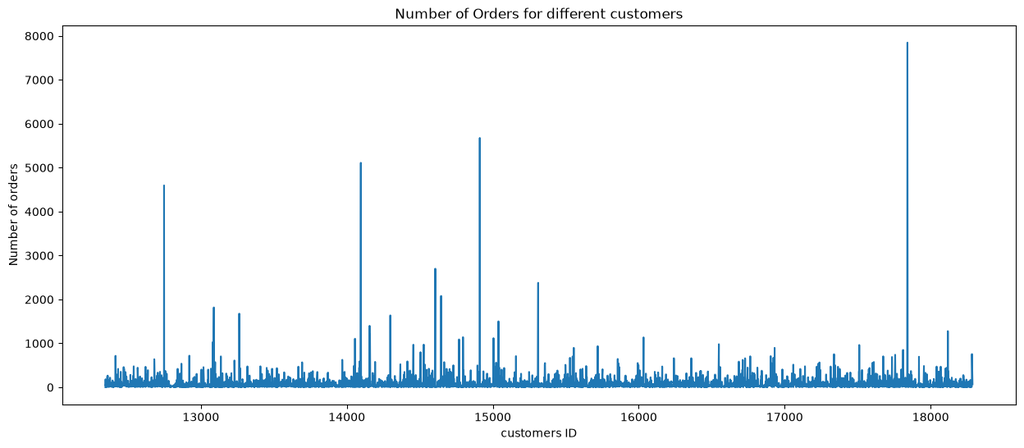

```python
orders = df_new.groupby(by=['cust_id','country'], as_index = False)['invoice_num'].count()
plt.subplots(figsize=(15,6))
plt.plot(orders.cust_id, orders.invoice_num)
plt.xlabel('customers ID')
plt.ylabel('Number of orders')
plt.title('Number of Orders for different customers')
plt.show()
```

```python
df_new.groupby(by = ['cust_id','country'])['amount_spent'].sum()
```

```
cust_id  country
12346    United Kingdom    77183.60
12347    Iceland            4310.00
12348    Finland            1797.24
12349    Italy              1757.55
12350    Norway              334.40
                             ...
18280    United Kingdom      180.60
18281    United Kingdom       80.82
18282    United Kingdom      178.05
18283    United Kingdom     2094.88
18287    United Kingdom     1837.28
Name: amount_spent, Length: 4347, dtype: float64
```

```python
money_spent = df_new.groupby(by = ['cust_id','country'], as_index = False)['amount_spent'].sum()
```

```python
money_spent
```

<style scoped> .dataframe tbody tr th:only-of-type { vertical-align: middle; } .dataframe tbody tr th { vertical-align: top; } .dataframe thead th { text-align: right; } </style> <thead> <th></th> <th>cust_id</th> <th>country</th> <th>amount_spent</th> </thead> <tbody> <th>0</th> <th>1</th> <th>2</th> <th>3</th> <th>4</th> <th>...</th> <th>4342</th> <th>4343</th> <th>4344</th> <th>4345</th> <th>4346</th> </tbody>

| 12346 | United Kingdom | 77183.60 |
| --- | --- | --- |
| 12347 | Iceland | 4310.00 |
| 12348 | Finland | 1797.24 |
| 12349 | Italy | 1757.55 |
| 12350 | Norway | 334.40 |
| ... | ... | ... |
| 18280 | United Kingdom | 180.60 |
| 18281 | United Kingdom | 80.82 |
| 18282 | United Kingdom | 178.05 |
| 18283 | United Kingdom | 2094.88 |
| 18287 | United Kingdom | 1837.28 |

<p>4347 rows × 3 columns</p>

```python
money_spent.sort_values(by = 'amount_spent', ascending = False).head()
```

<style scoped> .dataframe tbody tr th:only-of-type { vertical-align: middle; } .dataframe tbody tr th { vertical-align: top; } .dataframe thead th { text-align: right; } </style> <thead> <th></th> <th>cust_id</th> <th>country</th> <th>amount_spent</th> </thead> <tbody> <th>1698</th> <th>4210</th> <th>3737</th> <th>3017</th> <th>1888</th> </tbody>

| 14646 | Netherlands | 280206.02 |
| --- | --- | --- |
| 18102 | United Kingdom | 259657.30 |
| 17450 | United Kingdom | 194550.79 |
| 16446 | United Kingdom | 168472.50 |
| 14911 | EIRE | 143825.06 |

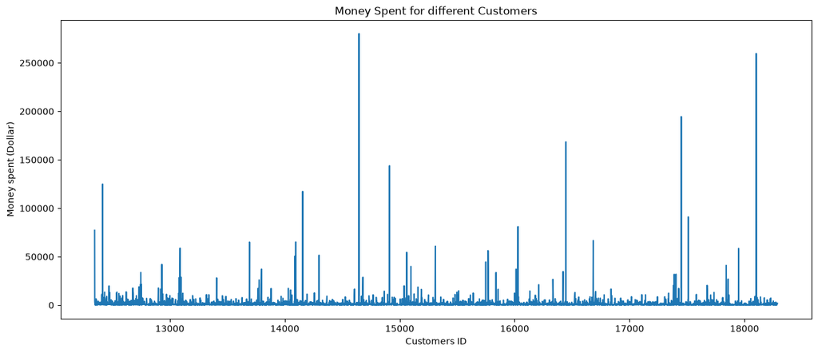

```python
money_spent = df_new.groupby(by=['cust_id', 'country'], as_index=False) ['amount_spent' ].sum()

plt.subplots (figsize=(15,6))

plt.plot (money_spent.cust_id, money_spent.amount_spent)

plt.xlabel('Customers ID')

plt.ylabel('Money spent (Dollar)')

plt.title("Money Spent for different Customers")

plt.show()
```

```python
df_new.head()
```

<style scoped> .dataframe tbody tr th:only-of-type { vertical-align: middle; } .dataframe tbody tr th { vertical-align: top; } .dataframe thead th { text-align: right; } </style> <thead> <th></th> <th>invoice_num</th> <th>invoice_date</th> <th>year_month</th> <th>month</th> <th>day</th> <th>hour</th> <th>stock_code</th> <th>description</th> <th>quantity</th> <th>unit_price</th> <th>amount_spent</th> <th>cust_id</th> <th>country</th> </thead> <tbody> <th>0</th> <th>1</th> <th>2</th> <th>3</th> <th>4</th> </tbody>

| 536365 | 2010-12-01 08:26:00 | 201012 | 12 | 3 | 8 | 85123A | white hanging heart t-light holder | 6 | 2.55 | 15.30 | 17850 | United Kingdom |
| --- | --- | --- | --- | --- | --- | --- | --- | --- | --- | --- | --- | --- |
| 536365 | 2010-12-01 08:26:00 | 201012 | 12 | 3 | 8 | 71053 | white metal lantern | 6 | 3.39 | 20.34 | 17850 | United Kingdom |
| 536365 | 2010-12-01 08:26:00 | 201012 | 12 | 3 | 8 | 84406B | cream cupid hearts coat hanger | 8 | 2.75 | 22.00 | 17850 | United Kingdom |
| 536365 | 2010-12-01 08:26:00 | 201012 | 12 | 3 | 8 | 84029G | knitted union flag hot water bottle | 6 | 3.39 | 20.34 | 17850 | United Kingdom |
| 536365 | 2010-12-01 08:26:00 | 201012 | 12 | 3 | 8 | 84029E | red woolly hottie white heart. | 6 | 3.39 | 20.34 | 17850 | United Kingdom |

```python
color = sns.color_palette()
```

```python
df_new.groupby('invoice_num')
```

```
<pandas.api.typing.DataFrameGroupBy object at 0x000002D9DF70A0B0>
```

```python
df_new.groupby('invoice_num')['year_month']
```

```
<pandas.api.typing.SeriesGroupBy object at 0x000002D9C547BCD0>
```

```python
df_new.groupby('invoice_num')['year_month'].unique()
```

```
invoice_num
536365    [201012]
536366    [201012]
536367    [201012]
536368    [201012]
536369    [201012]
            ...
581583    [201112]
581584    [201112]
581585    [201112]
581586    [201112]
581587    [201112]
Name: year_month, Length: 18536, dtype: object
```

```python
df_new.groupby('invoice_num')['year_month'].unique().value_counts()
```

```
year_month
[201111]    2658
[201110]    1929
[201109]    1756
[201105]    1555
[201012]    1400
[201106]    1393
[201107]    1331
[201103]    1321
[201108]    1281
[201104]    1149
[201102]     998
[201101]     987
[201112]     778
Name: count, dtype: int64
```

```python
df_new.groupby('invoice_num')['year_month'].unique().value_counts().sort_index()
```

```
year_month
[201012]    1400
[201101]     987
[201102]     998
[201103]    1321
[201104]    1149
[201105]    1555
[201106]    1393
[201107]    1331
[201108]    1281
[201109]    1756
[201110]    1929
[201111]    2658
[201112]     778
Name: count, dtype: int64
```

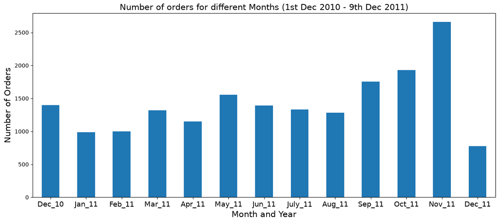

```python
ax = df_new.groupby('invoice_num')['year_month'].unique().value_counts().sort_index().plot(kind = 'bar',color = color[0],figsize = (15,6))

ax.set_xlabel('Month and Year',fontsize=15)
ax.set_ylabel('Number of Orders',fontsize=15)
ax.set_title('Number of orders for different Months (1st Dec 2010 - 9th Dec 2011)', fontsize=15)

t = ('Dec_10','Jan_11','Feb_11','Mar_11','Apr_11','May_11','Jun_11','July_11','Aug_11','Sep_11','Oct_11','Nov_11','Dec_11')

ax.set_xticklabels(t, rotation='horizontal', fontsize=13)

plt.show()
```

```python
df_new.groupby('invoice_num')
```

```
<pandas.api.typing.DataFrameGroupBy object at 0x000002D9E8694E10>
```

```python
df_new.groupby('invoice_num')['day']
```

```
<pandas.api.typing.SeriesGroupBy object at 0x000002D9E524FE30>
```

```python
df_new.groupby('invoice_num')['day'].unique()
```

```
invoice_num
536365    [3]
536366    [3]
536367    [3]
536368    [3]
536369    [3]
         ...
581583    [5]
581584    [5]
581585    [5]
581586    [5]
581587    [5]
Name: day, Length: 18536, dtype: object
```

```python
df_new.groupby('invoice_num')['day'].unique().value_counts()
```

```
day
[4]    4033
[3]    3455
[2]    3185
[1]    2863
[5]    2831
[7]    2169
Name: count, dtype: int64
```

```python
df_new.groupby('invoice_num')['day'].unique().value_counts().sort_index()
```

```
day
[1]    2863
[2]    3185
[3]    3455
[4]    4033
[5]    2831
[7]    2169
Name: count, dtype: int64
```

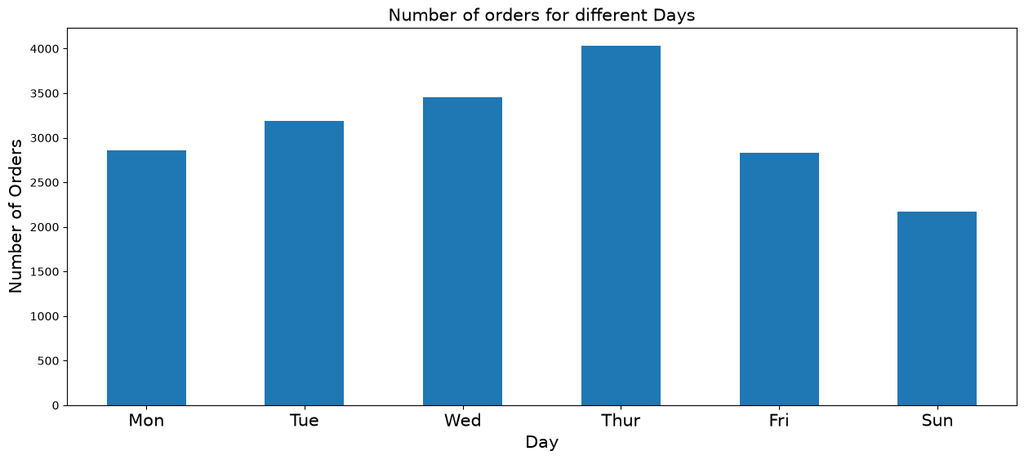

```python
ax = df_new.groupby('invoice_num')['day'].unique().value_counts().sort_index().plot(kind='bar', color=color[0], figsize=(15,6))

ax.set_xlabel('Day', fontsize=15)
ax.set_ylabel('Number of Orders', fontsize=15)
ax.set_title('Number of orders for different Days', fontsize=15)

d = ('Mon', 'Tue', 'Wed', 'Thur', 'Fri', 'Sun')

ax.set_xticklabels(d, rotation='horizontal', fontsize=15)

plt.show()
```

```python
df_new.unit_price.describe()
```

```
count    397924.000000
mean          3.116174
std          22.096788
min           0.000000
25%           1.250000
50%           1.950000
75%           3.750000
max        8142.750000
Name: unit_price, dtype: float64
```

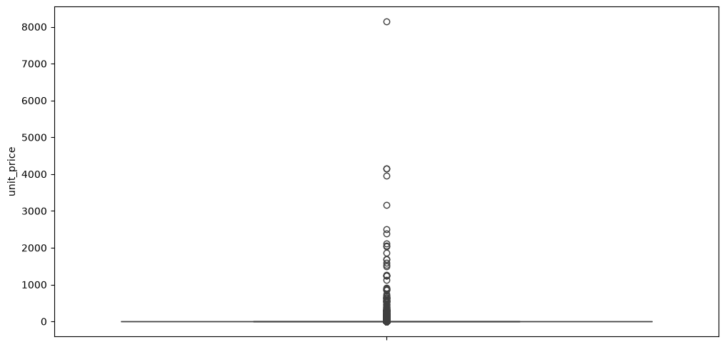

```python
#check the destribution of unit price
plt.subplots(figsize = (12,6))
sns.boxplot(df_new.unit_price)
plt.show()
```

```python
 df_free = df_new[df_new.unit_price == 0]
```

```python
len(df_free)
```

```
40
```

```python
df_free.year_month
```

```
9302      201012
33576     201012
40089     201012
47068     201101
47070     201101
56674     201101
86789     201102
130188    201103
139453    201103
145208    201104
157042    201104
187613    201105
198383    201105
279324    201107
282912    201107
```

[output cut: 26 more lines]

```python
df_free.year_month.value_counts()
```

```
year_month
201111    14
201108     6
201012     3
201101     3
201110     3
201103     2
201104     2
201105     2
201107     2
201109     2
201102     1
Name: count, dtype: int64
```

```python
df_free.year_month.value_counts().sort_index()
```

```
year_month
201012     3
201101     3
201102     1
201103     2
201104     2
201105     2
201107     2
201108     6
201109     2
201110     3
201111    14
Name: count, dtype: int64
```

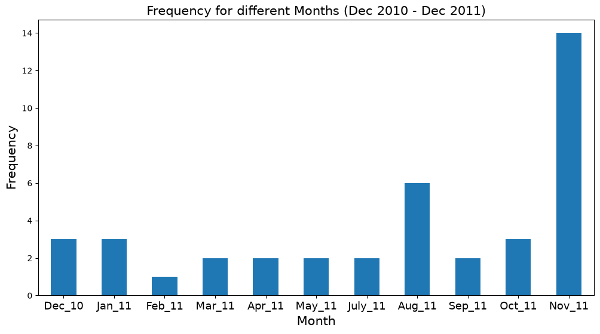

```python
ax = df_free.year_month.value_counts().sort_index().plot(kind='bar', figsize=(12,6), color=color[0])

ax.set_xlabel('Month', fontsize=15)
ax.set_ylabel('Frequency', fontsize=15)
ax.set_title('Frequency for different Months (Dec 2010 - Dec 2011)', fontsize=15)

m = ('Dec_10', 'Jan_11', 'Feb_11', 'Mar_11', 'Apr_11', 'May_11', 'July_11', 'Aug_11', 'Sep_11', 'Oct_11', 'Nov_11')

ax.set_xticklabels(m, rotation='horizontal', fontsize=13)

plt.show()
```

```python
df_new
```

<style scoped> .dataframe tbody tr th:only-of-type { vertical-align: middle; } .dataframe tbody tr th { vertical-align: top; } .dataframe thead th { text-align: right; } </style> <thead> <th></th> <th>invoice_num</th> <th>invoice_date</th> <th>year_month</th> <th>month</th> <th>day</th> <th>hour</th> <th>stock_code</th> <th>description</th> <th>quantity</th> <th>unit_price</th> <th>amount_spent</th> <th>cust_id</th> <th>country</th> </thead> <tbody> <th>0</th> <th>1</th> <th>2</th> <th>3</th> <th>4</th> <th>...</th> <th>541904</th> <th>541905</th> <th>541906</th> <th>541907</th> <th>541908</th> </tbody>

| 536365 | 2010-12-01 08:26:00 | 201012 | 12 | 3 | 8 | 85123A | white hanging heart t-light holder | 6 | 2.55 | 15.30 | 17850 | United Kingdom |
| --- | --- | --- | --- | --- | --- | --- | --- | --- | --- | --- | --- | --- |
| 536365 | 2010-12-01 08:26:00 | 201012 | 12 | 3 | 8 | 71053 | white metal lantern | 6 | 3.39 | 20.34 | 17850 | United Kingdom |
| 536365 | 2010-12-01 08:26:00 | 201012 | 12 | 3 | 8 | 84406B | cream cupid hearts coat hanger | 8 | 2.75 | 22.00 | 17850 | United Kingdom |
| 536365 | 2010-12-01 08:26:00 | 201012 | 12 | 3 | 8 | 84029G | knitted union flag hot water bottle | 6 | 3.39 | 20.34 | 17850 | United Kingdom |
| 536365 | 2010-12-01 08:26:00 | 201012 | 12 | 3 | 8 | 84029E | red woolly hottie white heart. | 6 | 3.39 | 20.34 | 17850 | United Kingdom |
| ... | ... | ... | ... | ... | ... | ... | ... | ... | ... | ... | ... | ... |
| 581587 | 2011-12-09 12:50:00 | 201112 | 12 | 5 | 12 | 22613 | pack of 20 spaceboy napkins | 12 | 0.85 | 10.20 | 12680 | France |
| 581587 | 2011-12-09 12:50:00 | 201112 | 12 | 5 | 12 | 22899 | children's apron dolly girl | 6 | 2.10 | 12.60 | 12680 | France |
| 581587 | 2011-12-09 12:50:00 | 201112 | 12 | 5 | 12 | 23254 | childrens cutlery dolly girl | 4 | 4.15 | 16.60 | 12680 | France |
| 581587 | 2011-12-09 12:50:00 | 201112 | 12 | 5 | 12 | 23255 | childrens cutlery circus parade | 4 | 4.15 | 16.60 | 12680 | France |
| 581587 | 2011-12-09 12:50:00 | 201112 | 12 | 5 | 12 | 22138 | baking set 9 piece retrospot | 3 | 4.95 | 14.85 | 12680 | France |

<p>397924 rows × 13 columns</p>

```python
df_new.groupby('country')
```

```
<pandas.api.typing.DataFrameGroupBy object at 0x000002D9E8B70680>
```

```python
df_new.groupby('country')['invoice_num']
```

```
<pandas.api.typing.SeriesGroupBy object at 0x000002D9E8696830>
```

```python
df_new.groupby('country')['invoice_num'].count()
```

```
country
Australia                 1185
Austria                    398
Bahrain                     17
Belgium                   2031
Brazil                      32
Canada                     151
Channel Islands            748
Cyprus                     614
Czech Republic              25
Denmark                    380
EIRE                      7238
European Community          60
Finland                    685
France                    8342
Germany                   9042
Greece                     145
Iceland                    182
Israel                     248
Italy                      758
Japan                      321
Lebanon                     45
Lithuania                   35
Malta                      112
Netherlands               2363
Norway                    1072
Poland                     330
Portugal                  1462
RSA                         58
Saudi Arabia                 9
Singapore                  222
Spain                     2485
Sweden                     451
Switzerland               1842
USA                        179
United Arab Emirates        68
United Kingdom          354345
Unspecified                244
Name: invoice_num, dtype: int64
```

```python
df_new.groupby('country')['invoice_num'].count().sort_values()
```

```
country
Saudi Arabia                 9
Bahrain                     17
Czech Republic              25
Brazil                      32
Lithuania                   35
Lebanon                     45
RSA                         58
European Community          60
United Arab Emirates        68
Malta                      112
Greece                     145
Canada                     151
USA                        179
Iceland                    182
Singapore                  222
Unspecified                244
Israel                     248
Japan                      321
Poland                     330
Denmark                    380
Austria                    398
Sweden                     451
Cyprus                     614
Finland                    685
Channel Islands            748
Italy                      758
Norway                    1072
Australia                 1185
Portugal                  1462
Switzerland               1842
Belgium                   2031
Netherlands               2363
Spain                     2485
EIRE                      7238
France                    8342
Germany                   9042
United Kingdom          354345
Name: invoice_num, dtype: int64
```

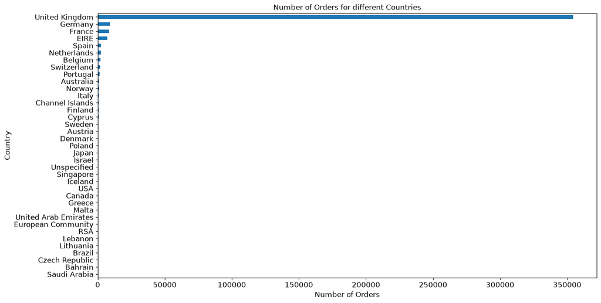

```python
group_country_orders = df_new.groupby('country')['invoice_num'].count().sort_values()

# del group_country_orders['United Kingdom']

# plot number of unique customers in each country (with UK)
plt.subplots(figsize=(15,8))
group_country_orders.plot(kind='barh', fontsize=12, color=color[0])
plt.xlabel('Number of Orders', fontsize=12)
plt.ylabel('Country', fontsize=12)
plt.title('Number of Orders for different Countries', fontsize=12)
plt.show()
```

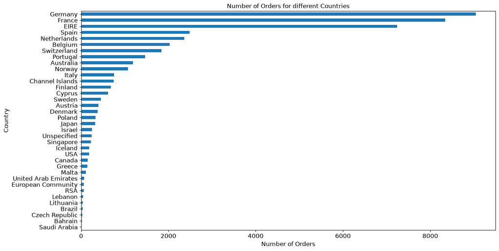

```python
group_country_orders = df_new.groupby('country')['invoice_num'].count().sort_values()

del group_country_orders['United Kingdom']

# plot number of unique customers in each country (with UK)
plt.subplots(figsize=(15,8))
group_country_orders.plot(kind='barh', fontsize=12, color=color[0])
plt.xlabel('Number of Orders', fontsize=12)
plt.ylabel('Country', fontsize=12)
plt.title('Number of Orders for different Countries', fontsize=12)
plt.show()
```

```python
#money spent by each country
df_new.groupby('country')['amount_spent'].sum()
```

```
country
Australia                138521.310
Austria                   10198.680
Bahrain                     548.400
Belgium                   41196.340
Brazil                     1143.600
Canada                     3666.380
Channel Islands           20450.440
Cyprus                    13590.380
Czech Republic              826.740
Denmark                   18955.340
EIRE                     265545.900
European Community         1300.250
Finland                   22546.080
France                   209024.050
Germany                  228867.140
Greece                     4760.520
Iceland                    4310.000
Israel                     7221.690
Italy                     17483.240
Japan                     37416.370
Lebanon                    1693.880
Lithuania                  1661.060
Malta                      2725.590
Netherlands              285446.340
Norway                    36165.440
Poland                     7334.650
Portugal                  33439.890
RSA                        1002.310
Saudi Arabia                145.920
Singapore                 21279.290
Spain                     61577.110
Sweden                    38378.330
Switzerland               56443.950
USA                        3580.390
United Arab Emirates       1902.280
United Kingdom          7308391.554
Unspecified                2667.070
Name: amount_spent, dtype: float64
```

```python
df_new.groupby('country')['amount_spent'].sum().sort_values()
```

```
country
Saudi Arabia                145.920
Bahrain                     548.400
Czech Republic              826.740
RSA                        1002.310
Brazil                     1143.600
European Community         1300.250
Lithuania                  1661.060
Lebanon                    1693.880
United Arab Emirates       1902.280
Unspecified                2667.070
Malta                      2725.590
USA                        3580.390
Canada                     3666.380
Iceland                    4310.000
Greece                     4760.520
Israel                     7221.690
Poland                     7334.650
Austria                   10198.680
Cyprus                    13590.380
Italy                     17483.240
Denmark                   18955.340
Channel Islands           20450.440
Singapore                 21279.290
Finland                   22546.080
Portugal                  33439.890
Norway                    36165.440
Japan                     37416.370
Sweden                    38378.330
Belgium                   41196.340
Switzerland               56443.950
Spain                     61577.110
Australia                138521.310
France                   209024.050
Germany                  228867.140
EIRE                     265545.900
Netherlands              285446.340
United Kingdom          7308391.554
Name: amount_spent, dtype: float64
```

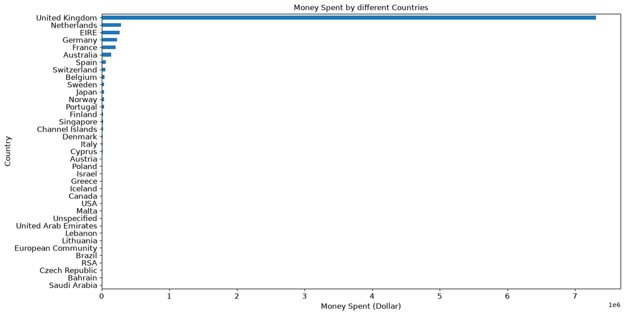

```python
group_country_amount_spent = df_new.groupby('country')['amount_spent'].sum().sort_values()

# del group_country_amount_spent['United Kingdom']

# plot total money spent by each country (with UK)
plt.subplots(figsize=(15,8))
group_country_amount_spent.plot(kind='barh', fontsize=12, color=color[0])
plt.xlabel('Money Spent (Dollar)', fontsize=12)
plt.ylabel('Country', fontsize=12)
plt.title('Money Spent by different Countries', fontsize=12)
plt.show()
```

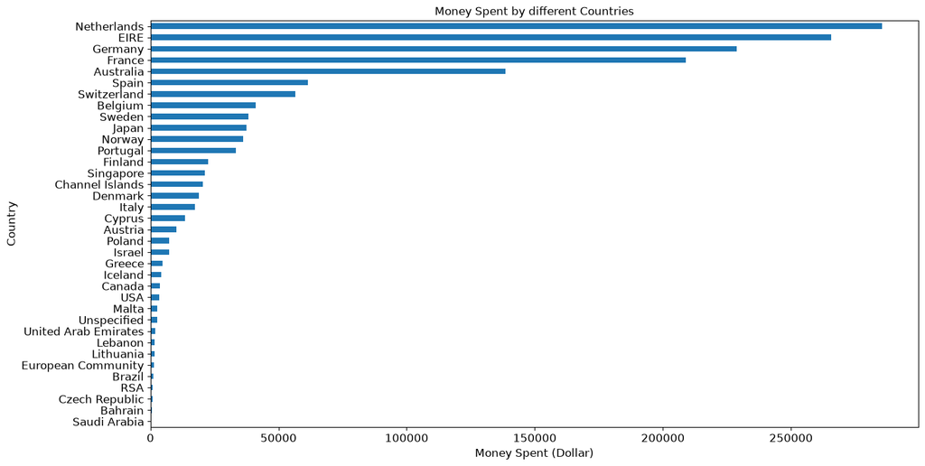

```python
group_country_amount_spent = df_new.groupby('country')['amount_spent'].sum().sort_values()

del group_country_amount_spent['United Kingdom']

# plot total money spent by each country (with UK)
plt.subplots(figsize=(15,8))
group_country_amount_spent.plot(kind='barh', fontsize=12, color=color[0])
plt.xlabel('Money Spent (Dollar)', fontsize=12)
plt.ylabel('Country', fontsize=12)
plt.title('Money Spent by different Countries', fontsize=12)
plt.show()
```

<h1 id="My-First-Data-Analysis-project-:)">My First Data Analysis project :)</h1>